# Kohler Microbiome Study: Publication Analysis

Edgardo L. Rosado Ramos

2025-11-21

# 1. Setup and Libraries

Load necessary packages for microbiome analysis and visualization.

```r
library(phyloseq)
library(vegan)
library(tidyverse)
library(ggplot2)
library(patchwork)
library(ggpubr)
library(DESeq2)
library(kableExtra)
library(indicspecies) # For Indicator Species Analysis
# Set a consistent theme for plots
theme_set(theme_bw(base_size = 12))
```

# 2. Data Loading and Processing

Reading OTU table, taxonomy, and metadata, then creating the phyloseq object.

```r
# --- Read OTU Table ---
otu_raw <- read.table("kohler.opti_mcc.0.03.subsample.shared", header = TRUE, sep = "\t")
otu_mat <- otu_raw[, -(1:3)]
rownames(otu_mat) <- otu_raw$Group
otu_mat <- t(otu_mat)
otu_tab <- otu_table(otu_mat, taxa_are_rows = TRUE)
# --- Read Taxonomy ---
tax_raw <- read.table("kohler.opti_mcc.0.03.cons.taxonomy",
                      sep = "\t", header = TRUE, stringsAsFactors = FALSE, quote = "")
taxonomy_strings <- tax_raw$Taxonomy
names(taxonomy_strings) <- tax_raw$OTU
taxonomy_clean <- lapply(strsplit(taxonomy_strings, ";"), function(x) {
  x <- x[nchar(x) > 0]
  x <- gsub("\\(.*?\\)|\\\"", "", x)
  trimws(x)
})
max_ranks <- 7
taxonomy_mat <- do.call(rbind, lapply(taxonomy_clean, `length<-`, max_ranks))
colnames(taxonomy_mat) <- c("Kingdom", "Phylum", "Class", "Order", "Family", "Genus", "Species")
rownames(taxonomy_mat) <- names(taxonomy_strings)
tax_tab <- tax_table(as.matrix(taxonomy_mat))
# --- Read Metadata ---
Kohler.design <- read.table("Kohlerdesign.txt",
                            header = TRUE,
                            sep = "\t",
                            row.names = 1,
                            stringsAsFactors = TRUE,
                            check.names = FALSE)
# --- Create Phyloseq Object ---
common_samples <- intersect(sample_names(otu_tab), rownames(Kohler.design))
otu_tab_pruned <- prune_samples(common_samples, otu_tab)
sample_data_obj <- sample_data(Kohler.design[common_samples, ])
physeq <- phyloseq(otu_tab_pruned, tax_tab, sample_data_obj)
print(physeq)
```

```
## phyloseq-class experiment-level object
## otu_table()   OTU Table:         [ 312 taxa and 32 samples ]
## sample_data() Sample Data:       [ 32 samples by 4 sample variables ]
## tax_table()   Taxonomy Table:    [ 312 taxa by 7 taxonomic ranks ]
```

## Rarefaction and Alpha Diversity Calculation

Filtering low-abundance taxa and rarefying to even depth for diversity analysis.

```r
# Filter taxa with < 3 counts in < 20% of samples (noise reduction)
physeq_filt <- filter_taxa(physeq, function(x) sum(x > 3) > (0.2 * length(x)), TRUE)
# Rarefy
min_depth <- min(sample_sums(physeq_filt))
set.seed(42)
physeq_rarefied <- rarefy_even_depth(physeq_filt, sample.size = min_depth, replace = FALSE)
# Calculate Alpha Diversity
alpha_diversity_rarefied <- estimate_richness(physeq_rarefied, measures = c("Observed", "Shannon"))
sample_metadata_rarefied <- as.data.frame(sample_data(physeq_rarefied))
alpha_data_rarefied <- cbind(alpha_diversity_rarefied, sample_metadata_rarefied)
# Order factors for plotting
age_order <- c("Fetus", "Newborn", "7+days", "15+days", "20+days")
alpha_data_rarefied$Age <- factor(alpha_data_rarefied$Age, levels = age_order)
```

# 3. Sample Size Analysis

Visualizing the distribution of samples across Age and Treatment groups to be transparent about study design limitations.

```r
# Summarize sample sizes
sample_summary <- alpha_data_rarefied %>%
  group_by(Age, SampleType) %>%
  summarise(n = n(), .groups = "drop")
print(sample_summary)
```

```
## # A tibble: 8 × 3
##   Age     SampleType     n
##   <fct>   <fct>      <int>
## 1 Fetus   Sterile        3
## 2 Newborn Newborn        3
## 3 7+days  Muck           5
## 4 7+days  Sterile        5
## 5 15+days Muck           3
## 6 15+days Sterile        8
## 7 20+days Muck           2
## 8 20+days Sterile        3
```

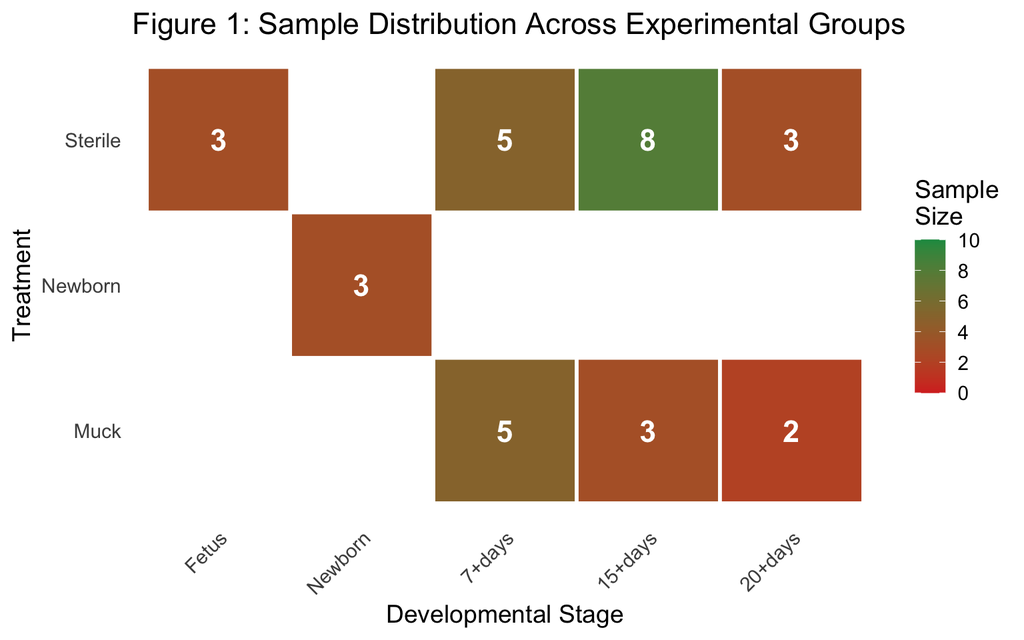

```r
# Create Heatmap
p_sample_dist <- ggplot(sample_summary, aes(x = Age, y = SampleType, fill = n)) +
  geom_tile(color = "white", size = 1) +
  geom_text(aes(label = n), size = 6, color = "white", fontface = "bold") +
  scale_fill_gradient(low = "#d73027", high = "#1a9850",
                      name = "Sample\nSize",
                      limits = c(0, 10),
                      breaks = c(0, 2, 4, 6, 8, 10)) +
  labs(title = "Figure 1: Sample Distribution Across Experimental Groups",
       x = "Developmental Stage", y = "Treatment") +
  theme_minimal(base_size = 14) +
  theme(panel.grid = element_blank(),
        axis.text.x = element_text(angle = 45, hjust = 1))
print(p_sample_dist)
```

```r
ggsave("Fig1_SampleDistribution.pdf", p_sample_dist, width = 8, height = 5)
```

# 4. Beta Diversity Analysis

Using PERMANOVA to test for effects of SampleType, Age, and Mother.

```r
# Calculate Bray-Curtis distance
bray_dist <- phyloseq::distance(physeq_rarefied, method = "bray")
# CRITICAL FIX: Ensure metadata is a standard data frame
# sample_data objects can sometimes cause issues in vegan functions
metadata <- data.frame(sample_data(physeq_rarefied))
# Standard PERMANOVA
set.seed(42)
permanova_standard <- adonis2(
  bray_dist ~ SampleType + Age + Mother,
  data = metadata,
  permutations = 9999,
  by = "margin"
)
print(permanova_standard)
```

```
## Permutation test for adonis under reduced model
## Marginal effects of terms
## Permutation: free
## Number of permutations: 9999
##
## adonis2(formula = bray_dist ~ SampleType + Age + Mother, data = metadata, permutations = 9999, by = "margin")
##            Df SumOfSqs      R2      F Pr(>F)
## SampleType  1   0.8758 0.11542 5.8263 0.0011 **
## Age         2   0.5135 0.06767 1.7081 0.0948 .
## Mother      3   1.6399 0.21611 3.6364 0.0001 ***
## Residual   23   3.4575 0.45563
## Total      31   7.5883 1.00000
## ---
## Signif. codes:  0 '***' 0.001 '**' 0.01 '*' 0.05 '.' 0.1 ' ' 1
```

```r
# Check Homogeneity of Dispersion (PERMDISP)
dispersion_sampletype <- betadisper(bray_dist, metadata$SampleType)
dispersion_age <- betadisper(bray_dist, metadata$Age)
dispersion_mother <- betadisper(bray_dist, metadata$Mother)
cat("PERMDISP p-values:\n")
```

```
## PERMDISP p-values:
```

```r
cat("SampleType:", anova(dispersion_sampletype)$`Pr(>F)`[1], "\n")
```

```
## SampleType: 0.5171933
```

```r
cat("Age:", anova(dispersion_age)$`Pr(>F)`[1], "\n")
```

```
## Age: 0.7660302
```

```r
cat("Mother:", anova(dispersion_mother)$`Pr(>F)`[1], "\n")
```

```
## Mother: 0.001674639
```

## Effect Size Summary

Calculating and tabulating effect sizes (R²) to emphasize biological relevance over just p-values.

```r
effect_size_table <- data.frame(
  Factor = c("Mother", "SampleType", "Age"),
  R2 = c(
    permanova_standard$R2[which(rownames(permanova_standard) == "Mother")],
    permanova_standard$R2[which(rownames(permanova_standard) == "SampleType")],
    permanova_standard$R2[which(rownames(permanova_standard) == "Age")]
  ),
  F_stat = c(
    permanova_standard$F[which(rownames(permanova_standard) == "Mother")],
    permanova_standard$F[which(rownames(permanova_standard) == "SampleType")],
    permanova_standard$F[which(rownames(permanova_standard) == "Age")]
  ),
  p_value = c(
    permanova_standard$`Pr(>F)`[which(rownames(permanova_standard) == "Mother")],
    permanova_standard$`Pr(>F)`[which(rownames(permanova_standard) == "SampleType")],
    permanova_standard$`Pr(>F)`[which(rownames(permanova_standard) == "Age")]
  )
) %>%
  mutate(
    R2_percent = round(R2 * 100, 1),
    Effect_Size = case_when(
      R2 < 0.01 ~ "Negligible",
      R2 < 0.06 ~ "Small",
      R2 < 0.14 ~ "Medium",
      TRUE ~ "Large"
    ),
    Significance = case_when(
      p_value < 0.001 ~ "***",
      p_value < 0.01 ~ "**",
      p_value < 0.05 ~ "*",
      TRUE ~ "ns"
    )
  )
knitr::kable(effect_size_table, caption = "Table 1: Effect Size Summary")
```

Table 1: Effect Size Summary

| Factor | R2 | F_stat | p_value | R2_percent | Effect_Size | Significance |
| --- | --- | --- | --- | --- | --- | --- |
| Mother | 0.2161093 | 3.636358 | 0.0001 | 21.6 | Large | *** |
| SampleType | 0.1154190 | 5.826289 | 0.0011 | 11.5 | Medium | ** |
| Age | 0.0676742 | 1.708077 | 0.0948 | 6.8 | Medium | ns |

```r
write.csv(effect_size_table, "Table1_EffectSizes.csv", row.names = FALSE)
```

# 5. Figure 2: Maternal Effects

Visualizing the strong maternal effect (R² ~ 20%) using PCoA, dispersion, and alpha diversity.

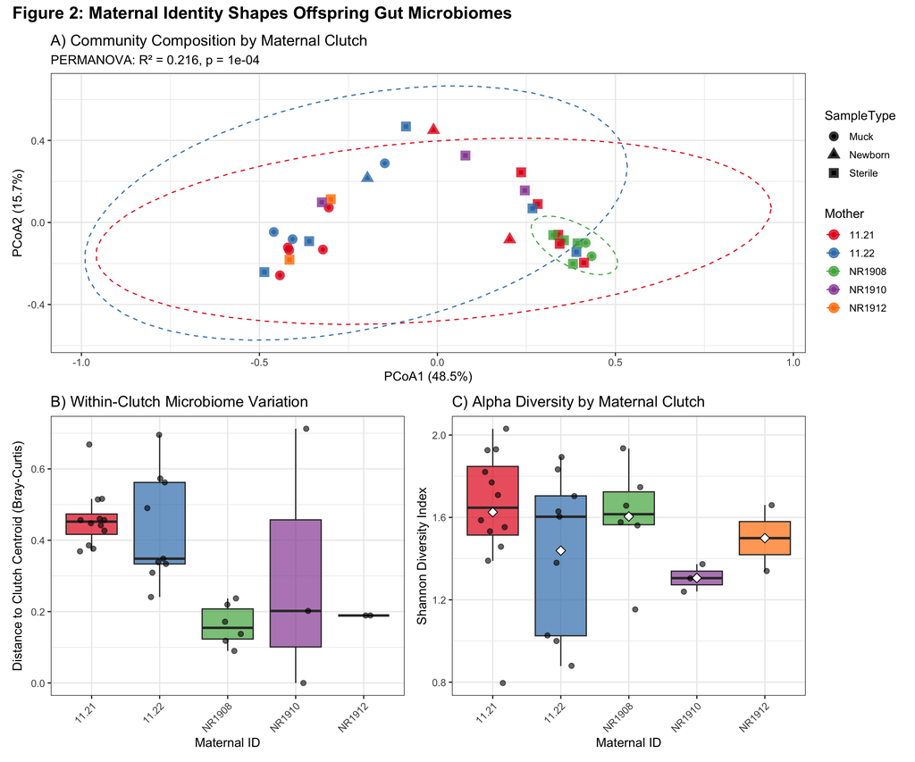

```r
# Panel A: PCoA colored by Mother
pcoa_res <- ordinate(physeq_rarefied, method = "PCoA", distance = bray_dist)
pcoa_mother <- plot_ordination(physeq_rarefied, pcoa_res,
                               color = "Mother", shape = "SampleType") +
  geom_point(size = 4, alpha = 0.8) +
  stat_ellipse(aes(group = Mother), linetype = 2, linewidth = 0.5) +
  scale_color_brewer(palette = "Set1") +
  labs(title = "A) Community Composition by Maternal Clutch",
       subtitle = paste0("PERMANOVA: R² = ",
                        round(effect_size_table$R2[1], 3),
                        ", p = ",
                        format.pval(effect_size_table$p_value[1], digits = 3)),
       x = paste0("PCoA1 (", round(pcoa_res$values$Relative_eig[1] * 100, 1), "%)"),
       y = paste0("PCoA2 (", round(pcoa_res$values$Relative_eig[2] * 100, 1), "%)"))
# Panel B: Dispersion within clutches
dispersion_df <- data.frame(
  Mother = metadata$Mother,
  Distance = dispersion_mother$distances
)
p_dispersion <- ggplot(dispersion_df, aes(x = Mother, y = Distance, fill = Mother)) +
  geom_boxplot(alpha = 0.7, outlier.shape = NA) +
  geom_jitter(width = 0.2, size = 2, alpha = 0.6) +
  scale_fill_brewer(palette = "Set1") +
  labs(title = "B) Within-Clutch Microbiome Variation",
       y = "Distance to Clutch Centroid (Bray-Curtis)",
       x = "Maternal ID") +
  theme(legend.position = "none",
        axis.text.x = element_text(angle = 45, hjust = 1))
# Panel C: Shannon diversity by Mother
p_alpha_mother <- ggplot(alpha_data_rarefied,
                         aes(x = Mother, y = Shannon, fill = Mother)) +
  geom_boxplot(alpha = 0.7, outlier.shape = NA) +
  geom_jitter(width = 0.2, size = 2, alpha = 0.6) +
  scale_fill_brewer(palette = "Set1") +
  stat_summary(fun = mean, geom = "point", shape = 23, size = 3,
               fill = "white", color = "black") +
  labs(title = "C) Alpha Diversity by Maternal Clutch",
       y = "Shannon Diversity Index",
       x = "Maternal ID") +
  theme(legend.position = "none",
        axis.text.x = element_text(angle = 45, hjust = 1))
# Combine panels
fig2 <- pcoa_mother / (p_dispersion | p_alpha_mother) +
  plot_annotation(
    title = "Figure 2: Maternal Identity Shapes Offspring Gut Microbiomes",
    theme = theme(plot.title = element_text(size = 16, face = "bold"))
  )
print(fig2)
```

```r
ggsave("Fig2_MaternalEffects.pdf", fig2, width = 12, height = 10)
```

# 6. Figure 3: Environmental Effects

Focusing on the well-powered age groups (7+days and 15+days) to show environmental effects.

[figure not shown]

```r
# Focus on well-powered age groups
physeq_subset <- subset_samples(physeq_rarefied,
                                Age %in% c("7+days", "15+days"))
bray_subset <- phyloseq::distance(physeq_subset, method = "bray")
pcoa_subset <- ordinate(physeq_subset, method = "PCoA", distance = bray_subset)
# Panel A: PCoA by SampleType
pcoa_env <- plot_ordination(physeq_subset, pcoa_subset,
                            color = "SampleType", shape = "Age") +
  geom_point(size = 4, alpha = 0.8) +
  stat_ellipse(aes(group = SampleType), linetype = 2, linewidth = 0.8) +
  scale_color_manual(values = c("Muck" = "#8c510a", "Sterile" = "#01665e")) +
  labs(title = "A) Community Composition by Environmental Exposure",
       subtitle = paste0("PERMANOVA: R² = ",
                        round(effect_size_table$R2[2], 3),
                        ", p = ",
                        format.pval(effect_size_table$p_value[2], digits = 3),
                        " (7+days and 15+days only)"),
       x = paste0("PCoA1 (", round(pcoa_subset$values$Relative_eig[1] * 100, 1), "%)"),
       y = paste0("PCoA2 (", round(pcoa_subset$values$Relative_eig[2] * 100, 1), "%)"))
# Panel B: Alpha diversity by SampleType
alpha_subset <- alpha_data_rarefied %>%
  filter(Age %in% c("7+days", "15+days"))
p_alpha_env <- ggplot(alpha_subset, aes(x = SampleType, y = Shannon,
                                        fill = SampleType)) +
  geom_boxplot(alpha = 0.7, outlier.shape = NA) +
  geom_jitter(width = 0.2, size = 2, alpha = 0.6) +
  scale_fill_manual(values = c("Muck" = "#8c510a", "Sterile" = "#01665e")) +
  stat_compare_means(method = "wilcox.test", label = "p.format") +
  labs(title = "B) Shannon Diversity by Treatment",
       subtitle = "7+days and 15+days only",
       y = "Shannon Diversity Index",
       x = "Treatment") +
  theme(legend.position = "none")
fig3 <- pcoa_env | p_alpha_env
print(fig3)
```

```r
ggsave("Fig3_EnvironmentalEffects.pdf", fig3, width = 14, height = 6)
```

# 8. Taxonomic Composition

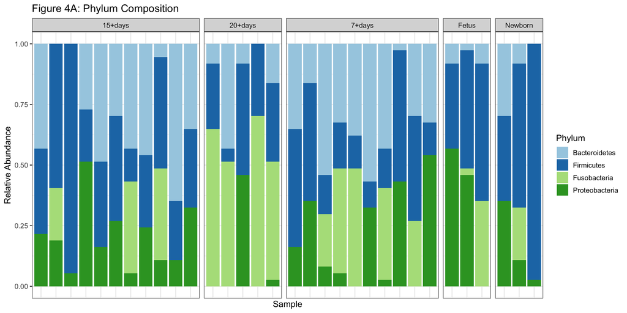

```r
# Agglomerate to Phylum
physeq_phylum <- tax_glom(physeq_rarefied, taxrank = "Phylum")
physeq_rel_p <- transform_sample_counts(physeq_phylum, function(x) x / sum(x))
melted_phy_p <- psmelt(physeq_rel_p)
# Top 10 Phyla
top_phyla <- names(sort(tapply(melted_phy_p$Abundance, melted_phy_p$Phylum, sum), decreasing = TRUE))[1:10]
melted_phy_p$Phylum_Collapsed <- ifelse(melted_phy_p$Phylum %in% top_phyla, as.character(melted_phy_p$Phylum), "Other")
p_phylum <- ggplot(melted_phy_p, aes(x = Sample, y = Abundance, fill = Phylum_Collapsed)) +
  geom_bar(stat = "identity", position = "stack") +
  facet_grid(~ Age, scales = "free_x", space = "free") +
  scale_fill_brewer(palette = "Paired", name = "Phylum") +
  labs(title = "Figure 4A: Phylum Composition", y = "Relative Abundance") +
  theme(axis.text.x = element_blank(), axis.ticks.x = element_blank())
print(p_phylum)
```

## B) Family Level Composition

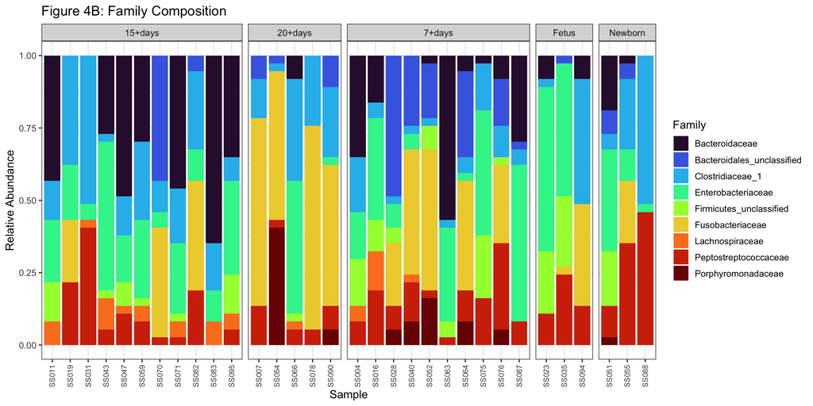

```r
# Agglomerate to Family
physeq_family <- tax_glom(physeq_rarefied, taxrank = "Family")
physeq_rel_f <- transform_sample_counts(physeq_family, function(x) x / sum(x))
melted_phy_f <- psmelt(physeq_rel_f)
# Top 15 Families
top_families <- names(sort(tapply(melted_phy_f$Abundance, melted_phy_f$Family, sum), decreasing = TRUE))[1:15]
melted_phy_f$Family_Collapsed <- ifelse(melted_phy_f$Family %in% top_families, as.character(melted_phy_f$Family), "Other")
p_family <- ggplot(melted_phy_f, aes(x = Sample, y = Abundance, fill = Family_Collapsed)) +
  geom_bar(stat = "identity", position = "stack") +
  facet_grid(~ Age, scales = "free_x", space = "free") +
  scale_fill_viridis_d(name = "Family", option = "turbo") + # Using turbo for more distinct colors
  labs(title = "Figure 4B: Family Composition", y = "Relative Abundance") +
  theme(axis.text.x = element_text(angle = 90, hjust = 1, vjust = 0.5, size = 8))
print(p_family)
```

```r
ggsave("Fig4_Taxonomy_Family.pdf", p_family, width = 12, height = 6)
```

## C) Heatmap of Top Genera

[figure not shown]

```r
# Filter to top 20 Genera
physeq_genus <- tax_glom(physeq_rarefied, taxrank = "Genus")
top20_genera <- names(sort(taxa_sums(physeq_genus), decreasing = TRUE))[1:20]
physeq_top20 <- prune_taxa(top20_genera, physeq_genus)
# Plot Heatmap
p_heatmap <- plot_heatmap(physeq_top20,
                          method = "NMDS",
                          distance = "bray",
                          sample.label = "SampleType",
                          taxa.label = "Genus") +
  facet_grid(~ Age, scales = "free_x", space = "free") +
  scale_fill_gradient(low = "white", high = "darkblue", na.value = "white") +
  labs(title = "Figure 5: Heatmap of Top 20 Genera") +
  theme(axis.text.x = element_text(angle = 90, hjust = 1))
print(p_heatmap)
```

```r
ggsave("Fig5_Heatmap.pdf", p_heatmap, width = 10, height = 8)
```

# 9. Differential Abundance (DESeq2)

Identifying specific taxa that differ between Muck and Sterile treatments (controlling for Age).

```r
# Convert phyloseq to DESeq2 object
# CRITICAL FIX: Subset to ages where both treatments exist to avoid "not full rank" error
# Fetus and Newborn only have one SampleType, which causes confounding.
physeq_deseq <- subset_samples(physeq, Age %in% c("7+days", "15+days", "20+days"))
# Remove taxa that are not present in this subset
physeq_deseq <- prune_taxa(taxa_sums(physeq_deseq) > 0, physeq_deseq)
ds_obj <- phyloseq_to_deseq2(physeq_deseq, ~ Age + SampleType)
# Run DESeq2
ds_res <- DESeq(ds_obj, test = "Wald", fitType = "parametric")
# Get results for Muck vs Sterile
res <- results(ds_res, contrast = c("SampleType", "Muck", "Sterile"))
# Filter for significance
sig_taxa <- as.data.frame(res) %>%
  filter(padj < 0.05) %>%
  arrange(desc(log2FoldChange))
# Add taxonomy
if (nrow(sig_taxa) > 0) {
  tax_info <- as.data.frame(tax_table(physeq)[rownames(sig_taxa), ])
  sig_taxa_annotated <- cbind(sig_taxa, tax_info)

  print("Differentially Abundant Taxa (Muck vs. Sterile):")
  knitr::kable(sig_taxa_annotated[, c("log2FoldChange", "padj", "Phylum", "Family", "Genus")],
               caption = "Table 3: Significant Differentially Abundant Taxa")
  write.csv(sig_taxa_annotated, "Table3_DifferentialAbundance.csv")
} else {
  print("No taxa found to be significantly different at FDR < 0.05")
}
```

```
## [1] "No taxa found to be significantly different at FDR < 0.05"
```

# 10. Indicator Species Analysis

An alternative to DESeq2 that looks for taxa that are “indicators” of a specific group (high fidelity and specificity). This is often more sensitive for presence/absence patterns.

```r
# Helper function to get readable taxonomy
get_tax_label <- function(physeq_obj, otu_id) {
  tax_df <- as.data.frame(tax_table(physeq_obj))
  tax_row <- tax_df[otu_id, ]
  label <- paste(tax_row$Family, tax_row$Genus, sep = "_")
  return(label)
}
# Subset to relevant ages (7+days, 15+days, 20+days)
physeq_indic <- subset_samples(physeq_rarefied, Age %in% c("7+days", "15+days", "20+days"))
physeq_indic <- prune_taxa(taxa_sums(physeq_indic) > 0, physeq_indic)
# Extract OTU table (species as columns)
otu_indic <- as(otu_table(physeq_indic), "matrix")
if(taxa_are_rows(physeq_indic)) { otu_indic <- t(otu_indic) }
# Extract grouping vector
groups_indic <- sample_data(physeq_indic)$SampleType
# Run Indicator Species Analysis
indval <- multipatt(otu_indic, groups_indic, control = how(nperm=999))
# Extract and annotate significant results
if (!is.null(indval$sign)) {
  sig_ind <- indval$sign %>%
    filter(p.value < 0.05)

  if (nrow(sig_ind) > 0) {
    # Add taxonomy
    tax_ind <- as.data.frame(tax_table(physeq_indic)[rownames(sig_ind), ])

    # Create readable label
    tax_ind$Label <- paste(rownames(tax_ind), tax_ind$Family, tax_ind$Genus, sep = " : ")

    results_ind <- cbind(sig_ind, tax_ind)

    print("Significant Indicator Species:")
    # Styled table using kableExtra for better HTML appearance
    print(
      knitr::kable(
        results_ind[, c("stat", "p.value", "Label")],
        caption = "Table 4: Indicator Species Analysis",
        col.names = c("Indicator Stat", "p-value", "Taxon"),
        align = "c"
      ) %>%
        kableExtra::kable_styling(
          bootstrap_options = c("striped", "hover", "condensed"),
          full_width = FALSE
        )
    )
    write.csv(results_ind, "Table4_IndicatorSpecies.csv")
  } else {
    print("No significant indicator species found.")
  }
}
```

```
## [1] "Significant Indicator Species:"
## <table class="table table-striped table-hover table-condensed" style="color: black; width: auto !important; margin-left: auto; margin-right: auto;">
## <caption>Table 4: Indicator Species Analysis</caption>
##  <thead>
##   <tr>
##    <th style="text-align:left;">  </th>
##    <th style="text-align:center;"> Indicator Stat </th>
##    <th style="text-align:center;"> p-value </th>
##    <th style="text-align:center;"> Taxon </th>
##   </tr>
##  </thead>
## <tbody>
##   <tr>
##    <td style="text-align:left;"> Otu0001 </td>
##    <td style="text-align:center;"> 0.7577391 </td>
##    <td style="text-align:center;"> 0.010 </td>
##    <td style="text-align:center;"> Otu0001 : Fusobacteriaceae : Cetobacterium </td>
##   </tr>
##   <tr>
##    <td style="text-align:left;"> Otu0006 </td>
##    <td style="text-align:center;"> 0.7980127 </td>
##    <td style="text-align:center;"> 0.018 </td>
##    <td style="text-align:center;"> Otu0006 : Enterobacteriaceae : Morganella </td>
##   </tr>
##   <tr>
##    <td style="text-align:left;"> Otu0007 </td>
##    <td style="text-align:center;"> 0.7588719 </td>
##    <td style="text-align:center;"> 0.014 </td>
##    <td style="text-align:center;"> Otu0007 : Bacteroidales_unclassified : Bacteroidales_unclassified </td>
##   </tr>
##   <tr>
##    <td style="text-align:left;"> Otu0014 </td>
##    <td style="text-align:center;"> 0.6281087 </td>
##    <td style="text-align:center;"> 0.046 </td>
##    <td style="text-align:center;"> Otu0014 : Porphyromonadaceae : Porphyromonadaceae_unclassified </td>
##   </tr>
## </tbody>
## </table>
```

# 11. Core Microbiome Analysis

Identifying the “Core” microbiome: taxa present in at least 50% of samples within a treatment group. This defines the stable resident community.

```r
# Function to get core taxa names
get_core_taxa <- function(physeq_obj, detection_threshold = 0, prevalence_threshold = 0.5) {
  # Transform to relative abundance
  physeq_rel <- transform_sample_counts(physeq_obj, function(x) x / sum(x))

  # Filter
  core_taxa <- filter_taxa(physeq_rel, function(x) sum(x > detection_threshold) > (prevalence_threshold * length(x)), TRUE)
  return(taxa_names(core_taxa))
}
# Get core for Muck
physeq_muck <- subset_samples(physeq_rarefied, SampleType == "Muck" & Age %in% c("7+days", "15+days", "20+days"))
core_muck <- get_core_taxa(physeq_muck)
# Get core for Sterile
physeq_sterile <- subset_samples(physeq_rarefied, SampleType == "Sterile" & Age %in% c("7+days", "15+days", "20+days"))
core_sterile <- get_core_taxa(physeq_sterile)
# Find shared and unique core taxa
shared_core <- intersect(core_muck, core_sterile)
unique_muck <- setdiff(core_muck, core_sterile)
unique_sterile <- setdiff(core_sterile, core_muck)
cat("Core Taxa Summary (Prevalence > 50%):\n")
```

```
## Core Taxa Summary (Prevalence > 50%):
```

```r
cat("Shared Core:", length(shared_core), "taxa\n")
```

```
## Shared Core: 3 taxa
```

```r
cat("Unique to Muck Core:", length(unique_muck), "taxa\n")
```

```
## Unique to Muck Core: 3 taxa
```

```r
cat("Unique to Sterile Core:", length(unique_sterile), "taxa\n")
```

```
## Unique to Sterile Core: 5 taxa
```

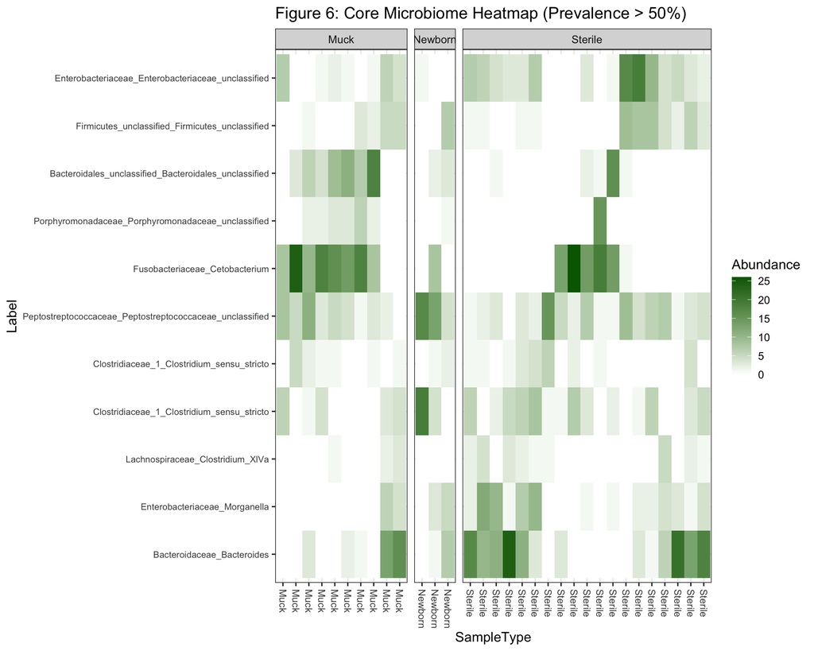

```
## [1] "Core Microbiome Taxa:"
## <table class="table table-striped table-hover table-condensed" style="color: black; width: auto !important; margin-left: auto; margin-right: auto;">
## <caption>Table 5: Core Microbiome Members (Prevalence &gt; 50%)</caption>
##  <thead>
##   <tr>
##    <th style="text-align:left;">  </th>
##    <th style="text-align:center;"> Core Status </th>
##    <th style="text-align:center;"> Family </th>
##    <th style="text-align:center;"> Genus </th>
##    <th style="text-align:center;"> Taxon (OTU : Family : Genus) </th>
##   </tr>
##  </thead>
## <tbody>
##   <tr>
##    <td style="text-align:left;"> Otu0001 </td>
##    <td style="text-align:center;"> Muck_Only </td>
##    <td style="text-align:center;"> Fusobacteriaceae </td>
##    <td style="text-align:center;"> Cetobacterium </td>
##    <td style="text-align:center;"> Otu0001 : Fusobacteriaceae : Cetobacterium </td>
##   </tr>
##   <tr>
##    <td style="text-align:left;"> Otu0002 </td>
##    <td style="text-align:center;"> Sterile_Only </td>
##    <td style="text-align:center;"> Bacteroidaceae </td>
##    <td style="text-align:center;"> Bacteroides </td>
##    <td style="text-align:center;"> Otu0002 : Bacteroidaceae : Bacteroides </td>
##   </tr>
##   <tr>
##    <td style="text-align:left;"> Otu0003 </td>
##    <td style="text-align:center;"> Shared </td>
##    <td style="text-align:center;"> Peptostreptococcaceae </td>
##    <td style="text-align:center;"> Peptostreptococcaceae_unclassified </td>
##    <td style="text-align:center;"> Otu0003 : Peptostreptococcaceae : Peptostreptococcaceae_unclassified </td>
##   </tr>
##   <tr>
##    <td style="text-align:left;"> Otu0004 </td>
##    <td style="text-align:center;"> Sterile_Only </td>
##    <td style="text-align:center;"> Clostridiaceae_1 </td>
##    <td style="text-align:center;"> Clostridium_sensu_stricto </td>
##    <td style="text-align:center;"> Otu0004 : Clostridiaceae_1 : Clostridium_sensu_stricto </td>
```

[output cut: 37 more lines]

```
##    <td style="text-align:left;"> Otu0013 </td>
##    <td style="text-align:center;"> Sterile_Only </td>
##    <td style="text-align:center;"> Lachnospiraceae </td>
##    <td style="text-align:center;"> Clostridium_XlVa </td>
##    <td style="text-align:center;"> Otu0013 : Lachnospiraceae : Clostridium_XlVa </td>
##   </tr>
##   <tr>
##    <td style="text-align:left;"> Otu0014 </td>
##    <td style="text-align:center;"> Muck_Only </td>
##    <td style="text-align:center;"> Porphyromonadaceae </td>
##    <td style="text-align:center;"> Porphyromonadaceae_unclassified </td>
##    <td style="text-align:center;"> Otu0014 : Porphyromonadaceae : Porphyromonadaceae_unclassified </td>
##   </tr>
## </tbody>
## </table>
```

```r
# Visualize Core Taxa (Heatmap of these specific taxa)
all_core <- c(shared_core, unique_muck, unique_sterile)
if(length(all_core) > 0) {
  physeq_core <- prune_taxa(all_core, physeq_rarefied)

  # Update taxa names to be readable for the plot
  tax_table(physeq_core) <- cbind(tax_table(physeq_core),
                                  Label = paste(tax_table(physeq_core)[,"Family"],
                                                tax_table(physeq_core)[,"Genus"], sep="_"))

  p_core <- plot_heatmap(physeq_core,
                         method = "NMDS",
                         distance = "bray",
                         sample.label = "SampleType",
                         taxa.label = "Label") + # Use the new Label column
    facet_grid(~ SampleType, scales = "free_x", space = "free") +
    scale_fill_gradient(low = "white", high = "darkgreen", na.value = "white") +
    labs(title = "Figure 6: Core Microbiome Heatmap (Prevalence > 50%)") +
    theme(axis.text.y = element_text(size = 8)) # Ensure labels are readable

  print(p_core)
  ggsave("Fig6_CoreMicrobiome.pdf", p_core, width = 10, height = 8)

  # Save list of core taxa with names
  core_tax_table <- as.data.frame(tax_table(physeq_core))
  core_tax_table$Core_Status <- case_when(
    rownames(core_tax_table) %in% shared_core ~ "Shared",
    rownames(core_tax_table) %in% unique_muck ~ "Muck_Only",
    rownames(core_tax_table) %in% unique_sterile ~ "Sterile_Only"
  )

  # Create readable label for the table
  core_tax_table$Label <- paste(rownames(core_tax_table), core_tax_table$Family, core_tax_table$Genus, sep = " : ")

  print("Core Microbiome Taxa:")
  # Prepare a tidy table with separate taxonomic columns
  core_tax_table <- core_tax_table %>%
    dplyr::select(Core_Status, Family, Genus, Label) %>%
    dplyr::rename(
      "Core Status" = Core_Status,
      "Family" = Family,
      "Genus" = Genus,
      "Taxon (OTU : Family : Genus)" = Label
    )

  # Styled table using kableExtra for a polished HTML look
  print(
    knitr::kable(core_tax_table,
                 caption = "Table 5: Core Microbiome Members (Prevalence > 50%)",
                 align = "c") %>%
      kableExtra::kable_styling(
        bootstrap_options = c("striped", "hover", "condensed"),
        full_width = FALSE
      )
  )

  # Save the formatted table for manuscript use
  write.csv(core_tax_table, "Table5_CoreTaxa.csv", row.names = FALSE)
}
```

# 12. Summary Statistics

```r
summary_stats <- alpha_data_rarefied %>%
  group_by(SampleType, Age) %>%
  summarise(
    n = n(),
    Shannon_mean = mean(Shannon, na.rm = TRUE),
    Shannon_sd = sd(Shannon, na.rm = TRUE),
    Shannon_se = sd(Shannon, na.rm = TRUE) / sqrt(n()),
    Observed_mean = mean(Observed, na.rm = TRUE),
    Observed_sd = sd(Observed, na.rm = TRUE),
    .groups = "drop"
  ) %>%
  mutate(
    Shannon_summary = paste0(round(Shannon_mean, 2), " ± ", round(Shannon_se, 2)),
    Observed_summary = paste0(round(Observed_mean, 1), " ± ", round(Observed_sd, 1))
  )
# Select and rename columns for a "pretty" publication-ready table
pretty_table <- summary_stats %>%
  dplyr::select(SampleType, Age, n, Shannon_summary, Observed_summary) %>%
  dplyr::rename(
    "Treatment" = SampleType,
    "Developmental Stage" = Age,
    "Sample Size (n)" = n,
    "Shannon Index (Mean ± SE)" = Shannon_summary,
    "Observed OTUs (Mean ± SD)" = Observed_summary
  )
print(knitr::kable(pretty_table,
             caption = "Table 2: Summary Statistics of Alpha Diversity",
             align = "c"))
```

```
##
##
## Table: Table 2: Summary Statistics of Alpha Diversity
##
## | Treatment | Developmental Stage | Sample Size (n) | Shannon Index (Mean ± SE) | Observed OTUs (Mean ± SD) |
## |:---------:|:-------------------:|:---------------:|:-------------------------:|:-------------------------:|
## |   Muck    |       7+days        |        5        |        1.59 ± 0.06        |         7.6 ± 0.9         |
## |   Muck    |       15+days       |        3        |        1.67 ± 0.04        |         6.3 ± 1.2         |
## |   Muck    |       20+days       |        2        |        1.33 ± 0.3         |          6 ± 2.8          |
## |  Newborn  |       Newborn       |        3        |        1.52 ± 0.36        |         6.7 ± 3.2         |
## |  Sterile  |        Fetus        |        3        |        1.31 ± 0.04        |         5.3 ± 0.6         |
## |  Sterile  |       7+days        |        5        |        1.77 ± 0.11        |         7.6 ± 0.9         |
## |  Sterile  |       15+days       |        8        |        1.54 ± 0.09        |          7.2 ± 1          |
## |  Sterile  |       20+days       |        3        |        1.26 ± 0.32        |          6 ± 2.6          |
```

```r
# Save the raw stats
write.csv(summary_stats, "Table2_SummaryStats_Raw.csv", row.names = FALSE)
# Save the pretty formatted table for the manuscript
write.csv(pretty_table, "Table2_SummaryStats_Formatted.csv", row.names = FALSE)
```